# Analysis of OMICS data, practical 9

Functional enrichment analysis

Author

Affiliation

Eszter Ari

Eötvös Loránd University, Budapest & Biological Research Centre, Szeged

Published

April 24, 2026

**Useful videos:**

- [General introduction to overrepresentation analysis](https://youtu.be/tYLd1LtxYiI?t=3377): watch it from min. 56:17 to 1:04:00
- [Fisher’s exact test](https://youtu.be/udyAvvaMjfM)
- [Gene set enrichment analysis (GSEA) and the Kolmogorov-Smirnov test](https://youtu.be/bT00oJh2x_4)

**The description of the practical is based on Guangchuang Yu’s book: [clusterProfiler: universal enrichment tool for functional and comparative study](http://yulab-smu.top/clusterProfiler-book/index.html), Altuna Akalin’s book: [Computational Genomics with R](https://compgenomr.github.io/book/), and the [README of the *mulea* R package](https://github.com/ELTEbioinformatics/mulea).**

# Description of the practical

At this practical, we will use the `RStudio Server` of the *dlab*: https://rstudio.dlab.elte.hu/.

**After this practical, you will be able to:**

- Understand how functional enrichment analyses work.
- Use the `mulea` R package (Turek et al. 2024), a universal enrichment tool
- Understand and visualise the enrichment results

The **Questions** will be denoted by boxes, as follows:

**NoteT0 Q0**

Questions to solve go here.

## The dataset and the environment

We will use the results of the previous practical. You can write it to a comma-separated table (*csv*) by applying this command in your script for **Practical 8**:

```r
write.csv(DEresults, "DEresults.csv")
```

Or you can use the table available at the /shared/OMICS/practical_10/ directory as well.

## IDs

Please notice that we use *gene symbols* as identifiers of genes here. There are several different **IDs** for genes and proteins (*e.g.,* *UniprotIDs*, *EnsemblIDs*, *gene names*, *etc.*), and it is always **important to be aware of what IDs we have**. We have to have the same kind of IDs in the ontology (*i.e.* gene lists of *GO* terms) to be able to run the enrichment test. You can map different IDs with dedicated software, an R package, or [UniProt’s ID mapping website](https://www.uniprot.org/id-mapping).

### Setting up the environment

- Create a new `Project` in `RStudio server`.
- Create a directory for the project named Functional_enrichment_analysis.
- Open a new R Script file and save it.

# Introduction

Researchers performing high-throughput experiments that yield sets of genes (for example, genes that are differentially expressed under different conditions) often want to retrieve a functional profile of those genes, to better understand the underlying biological processes. This can be done by comparing the significantly differentially expressed genes or genes that are ordered by *logFC* to gene sets in the [*Gene Ontology (GO) database*](https://en.wikipedia.org/wiki/Gene_ontology) or to other collections and ontologies of gene sets. A **gene set** is an *unordered* collection of genes with some common property (*i.e.*, functional relatedness). This shared property among a set of genes could be a shared *GO* term, a common *biological pathway* (a pathway can be interpreted as a gene set by ignoring functional relationships among genes), a shared *interaction partner*, a shared *transcription factor* or any biologically relevant commonality that is meaningful in the context of the pursued experiment.

## Gene Ontology (GO)

In a typical differential expression analysis, *thousands* of genes are found differentially expressed between two groups of samples. While prior knowledge of the functions of individual genes can give some clues about what kind of cellular processes have been affected, *e.g.,* by a drug treatment, manually going through the whole list of thousands of genes would be very cumbersome and not very informative in the end. Therefore, a commonly used tool to address this problem is to do **enrichment analyses of functional terms** that appear **associated with the given set of differentially expressed genes** more often than expected by chance. The functional terms are usually associated with multiple genes. Thus, genes can be grouped into sets by shared functional terms. However, it is important to have an agreed-upon controlled vocabulary on the list of terms used to describe the functions of genes. Otherwise, it would be impossible to exchange scientific results globally. That’s why initiatives such as the [*Gene Ontology Consortium*](http://www.geneontology.org/) have collated a list of terms for each gene. *GO* term enrichment analysis is probably the most common analysis applied after a differential expression analysis. *GO* term analysis helps quickly find out systematic changes that can describe differences between groups of samples.

**Gene Ontology** defines concepts/classes used to describe gene function, and relationships between these concepts. It classifies functions along three aspects:

- MF: Molecular Function
  - molecular activities of gene products
- CC: Cellular Component
  - where gene products are active
- BP: Biological Process
  - pathways and larger processes made up of the activities of multiple gene products

*GO* terms are organised in a directed acyclic graph, where an edge between the terms represents a parent-child relationship.

An example of the hierarchy tree for *GO* terms. The functions and relative amount of genes for *Staphylococcus aureus* HG003 can be shown in the tree. ([source](https://www.researchgate.net/publication/331074903_Development_and_application_of_computational_tools_for_RNA-Seq_based_transcriptome_annotations))

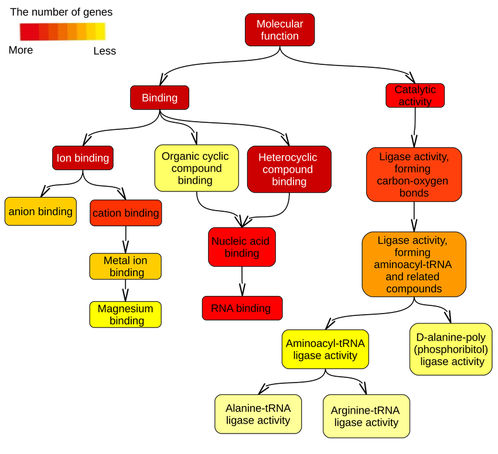

## Other ontologies

We can expand beyond traditional GO enrichment analysis by testing the enrichment of a wide range of ontologies, encompassing pathways, regulatory elements, genomic locations, and protein domains. This flexibility enables researchers to tailor enrichment analysis to their specific questions, such as identifying enriched transcriptional regulators in gene expression data or overrepresented protein domains in protein sets.

### Pathways

Biological pathways provide intuitive views of the myriad of interactions underlying biological processes. A typical signalling pathway, for example, can represent receptor-binding events, protein complexes, phosphorylation reactions, translocations and transcriptional regulation, with only a minimal set of symbols, lines and arrows. These powerful representations are essential tools, common among the textbooks and review articles that document any given field of biology. Making these tools available for computational methods of analysis will allow researchers to connect pathways to databases of biological annotations and experimental data, creating effective products of systems biology. Collecting and maintaining pathway information in a robust database, however, is an ongoing challenge.

#### WikiPathways

[WikiPathways](https://www.wikipathways.org/) (Martens et al. 2021) was established to facilitate the contribution and maintenance of pathway information by the biology community. WikiPathways is an open, collaborative platform dedicated to the curation of biological pathways. WikiPathways thus presents a new model for pathway databases that enhances and complements ongoing efforts, such as KEGG, Reactome and Pathway Commons. The familiar web-based format of WikiPathways greatly reduces the barrier to participating in pathway modelling. More importantly, the open, public approach of WikiPathways allows for broader participation by the entire community, ranging from students to senior experts in each field. This approach also shifts the bulk of peer review, editorial review, and maintenance to the community.

## The GMT Ontology File Format

The [GMT (Gene Matrix Transposed)](https://software.broadinstitute.org/cancer/software/gsea/wiki/index.php/Data_formats#GMT:_Gene_Matrix_Transposed_file_format_.28.2A.gmt.29) format contains collections of genes or proteins associated with specific ontology terms in a tab-delimited text file. Each term is represented by a single row in both the GMT file and the data frame. Each row includes three types of elements:

1. **Ontology identifier** (“*ontology_id*”): This uniquely identifies each term within the file or data frame.
2. **Ontology name or description** (*“ontology_name”*): This provides a user-friendly label or textual description for each term.
3. **Associated gene or protein identifiers**: These are listed in the *“list_of_values”* column, with identifiers separated by spaces, and belong to each term.

## Functional Enrichment Analysis Methods

There are basically two approaches to do this kind of testing: **Gene Set Overrepresentation Analysis (ORA)** and **Gene Set Enrichment Analysis (GSEA)**.

### Over Representation Analysis (ORA)

*Over Representation Analysis* (Boyle et al. 2004) is a widely used approach to determine whether known biological functions or processes are over-represented (= enriched) in an experimentally-derived gene list, *e.g.,* a list of differentially expressed genes.

#### The input data of ORA

- Differentially over expressed genes (where *e.g.,* $p-value < 0.05$ and $log2FC > 0$)
- Genes whose expression was measured during the experiment.
- Gene sets belong to the database with which we are testing the enrichment (*i.e.* genes of *GO terms*)

#### Statistical test of ORA

The $p-value$ can be calculated using the **hypergeometric distribution**.

[output not shown]

$p = 1 - \displaystyle\sum_{i = 0}^{k-1}\frac{{K \choose k}{{N-K} \choose {n-k}}} {{N \choose n}}$

$p-values$ should be adjusted for [multiple comparison](https://en.wikipedia.org/wiki/Multiple_comparisons_problem) (which is also called as *False Discovery Rate (FDR)* correction).

#### Example of how to calculate ORA

```r
d <- matrix(c(28, 2613, 29, 15310),
         nrow = 2,
         dimnames = list(c("DE", "Not DE"),
                         c("In gene set", "Not in gene set")))
```

|  | **In the gene set** | **Not in the gene set** |
| --- | --- | --- |
| **DE genes** | 28 | 29 |
| **Not DE genes** | 2,613 | 15,310 |

Whether the overlap of 28 genes is significantly over-represented in the gene set can be assessed using the hypergeometric distribution. This corresponds to a one-sided version of **Fisher’s exact test**.

### **Task 1**: Calculating the one-sided version (“greater”) of *Fisher’s exact test*

**NoteT1 Q1**

What `R` function did you use and how? Copy the code here.

**NoteT1 Q2**

What $p-value$ do you get with Fisher’s exact test?

**NoteT1 Q3**

What does this $p-value$ mean?

## False Discovery Rate

False Discovery Rate (FDR) (Benjamini and Hochberg 1995) is a simple multiple testing correction that measures the expected proportion of false positive matches (Type I errors) within results. *Benjamini-Hochberg* FDR approach takes into account $p-values$ observed in the experiment. The latter is often considered more applicable for Gene Ontology analysis than the *Bonferroni* correction.

For the overrepresentation analysis, `mulea` employs a progressive *empirical false discovery rate (eFDR)* method, specifically designed for interconnected biological data, to accurately identify significant terms within diverse ontologies.

# **Task 2**: Calculating ORA in *GO* terms

In `R`, there are several packages available to do enrichment analysis. Here we will apply the package `mulea` to demonstrate how to do ORA.

## Target Gene Set and Background Gene Set

The “background set” will be all the genes that were involved in the differential expression analysis.

```r
# read in the differential expression results
DEresults <- read.csv("DEresults.csv",
                      row.names = 1)

# remove genes with NA values
DEresults <- DEresults[!is.na(DEresults$padj), ]

# create the vector of all expressed genes
# as the background gene set
background_set <- rownames(DEresults)

# select genes with adjusted p-values below 0.05
DE <- DEresults[DEresults$padj < 0.05, ]

# select genes with positive log2 fold change
DE <- DE[DE$log2FoldChange > 1, ]

# create the vector of differentially expressed genes
# as the target gene set
target_set <- rownames(DE)
```

**NoteT2 Q1**

How many genes can be found in the target and in the background gene sets?

## The Gene Onology GMT

We will read a GMT file containing the gene sets belonging to the Biological Process *GO* terms (of *Homo sapiens*, with Gene Symbol IDs) using the `read_gmt` function or the `mulea` package.

Read the GMT file that was previously downloaded from the [GMT_files_for_mulea](https://github.com/ELTEbioinformatics/GMT_files_for_mulea/) Github repository, and which can be found in the /shared/OMICS/practical_10/ directory.

```r
library(mulea)

go_ontology <- read_gmt("GO_BP_Homo_sapiens_GeneSymbol.gmt")
# for technical reasons, change the content of column ontology_id and ontology_name
colnames(go_ontology)[1:2] <- c("ontology_name", "ontology_id")
go_ontology <- go_ontology[,c(2,1,3)]
```

### Filtering the Ontology

Enrichment analysis results can sometimes be skewed by overly specific or broad entries. `mulea` allows you to customise the size of ontology entries – the number of genes or proteins belonging to a term – ensuring your analysis aligns with your desired scope.

Let’s exclude ontology entries with fewer than 3 or more than 400 gene symbols.

```r
# Filtering the ontology
go_ontology_filtered <- filter_ontology(gmt = go_ontology,
                                        min_nr_of_elements = 3,
                                        max_nr_of_elements = 400)
```

**NoteT2 Q2**

How many GO terms (ontology entries) can be found in the Biological Process Gene Ontology? How many have remained after filtering?

### Performing the OverRepresentation Analysis

```r
# Creating the ORA model using the GMT variable
ora_model <- ora(gmt = go_ontology_filtered,
                 # Test set variable
                 element_names = target_set,
                 # Background set variable
                 background_element_names = background_set,
                 # p-value adjustment method
                 p_value_adjustment_method = "eFDR",
                 # Number of permutations
                 number_of_permutations = 1000,
                 # Number of processor threads to use
                 nthreads = 2,
                 # Setting a random seed for reproducibility
                 random_seed = 1)

# Running the ORA
ora_results <- run_test(ora_model)
```

### Examining the ORA Result

The `ora_results` data frame summarises the enrichment analysis, listing ontology entries – in our case Gene Ontology IDs and terms – alongside their associated *p*-values and *eFDR* values.

We can now determine the “significantly enriched” GO terms based on these statistical measures (*eFDR* < 0.05).

Inspect the significant results using the `dplyr` R package:

```r
library(dplyr)

sign_ora_results <- ora_results %>%
  # Arrange the rows by the eFDR values
  arrange(eFDR) %>%
  # Rows where the eFDR < 0.05
  filter(eFDR < 0.05)
```

**NoteT2 Q3**

In how many GO terms was our target gene set significantly enriched?

**NoteT2 Q4**

What are the 3 most significant GO terms in the result table?

## **Task 3**: Visualising the ORA Result

To gain a comprehensive understanding of the enriched transcription factors, `mulea` offers diverse visualisation tools, including lollipop charts, bar plots, networks, and heatmaps. These visualisations effectively reveal patterns and relationships among the enriched factors.

Initialising the visualisation with the `reshape_results` function:

```r
# Reshaping the ORA results for visualisation
ora_reshaped_results <- reshape_results(model = ora_model,
                                        model_results = ora_results,
                                        # Choosing which column to use for the
                                        #     indication of significance
                                        p_value_type_colname = "eFDR")
```

### Visualising the Spread of *eFDR* Values: Lollipop Plot

Lollipop charts provide a graphical representation of the distribution of enriched Gene Ontology entries. The *y*-axis displays the GO terms, while the *x*-axis represents their corresponding *eFDR* values. The dots are coloured based on their *eFDR* values. This visualisation helps us examine the spread of *eFDRs* and identify factors exceeding the significance threshold of 0.05.

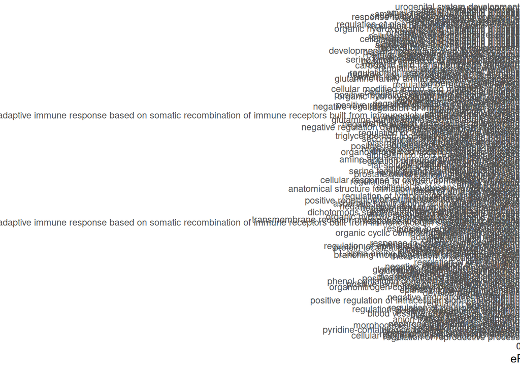

```r
plot_lollipop(reshaped_results = ora_reshaped_results,
              # Upper threshold for the value indicating the significance
              p_value_max_threshold = 0.05,
              # Column that indicates the significance values
              p_value_type_colname = "eFDR")
```

As we see, there are too many enriched terms to visualise all of them.

**NoteT3 Q1**

Create a lollipop plot only for the GO terms for which the *eFDR* < 0.0005.

## **Task 4**: Run a similar ORA analysis using the WikiPathways GMT

Read the GMT file that was previously downloaded from the [GMT_files_for_mulea](https://github.com/ELTEbioinformatics/GMT_files_for_mulea/) GitHub repository, which can be found in the /shared/OMICS/practical_10/ directory.

Instead of the lollipop plot, create a graph plot for the pathways for which the *eFDR* < 0.0001, using the `plot_graph` function.

**Visualising the Associations: Graph Plot**

This function generates a network visualisation of the enriched ontology categories (*e.g.*, transcription factors). Each node represents an enriched ontology category, coloured based on its *eFDR* value. An edge is drawn between two nodes if they share at least one common gene belonging to the target set, indicating co-regulation. The thickness of the edge reflects the number of shared genes.

**TipHint**

There is no need to change the content of columns “ontology_id” and “ontology_name” for the *WikiPathways* GMT file, as it is already in the correct format.

**NoteT4 Q1**

Create a graph plot for the *WikiPathways* entries for which the *eFDR* < 0.0001. Based on the graph plot, which enriched pathways share the highest number of genes? Approximately how many genes are shared between these?

# **Task 5**: Calculate Gene Set Enrichment (GSEA) with mulea using the WikiPathways GMT

## Gene Set Enrichment Analysis (GSEA)

In *Gene Set Enrichment Analysis (GSEA)* (Subramanian et al. 2005), all genes that were involved in the original experiment (RNA-seq or microarray) can be used. *GSEA* aggregates the per gene statistics across genes within a gene set (*i.e.* a pathway), therefore making it possible to detect situations where all genes in a predefined set change in a small but coordinated way. Since it is likely that many relevant phenotypic differences are manifested by small but consistent changes in a set of genes.

### The input data of GSEA

- Genes whose expression was measured during the experiment were ranked by $log2FC$
- Gene sets belong to the database with which we are testing the enrichment (*i.e.*, genes of each pathway)

### Statistical test of GSEA

Genes are ranked based on their phenotypes. Given a priori defined set of genes $S$ (*e.g.*, genes sharing the same pathway), the goal of GSEA is to determine whether the members of $S$ are randomly distributed throughout the ranked gene list ($L$) or primarily found at the top or bottom.

There are three key elements of the GSEA method:

- Calculation of an Enrichment Score.
  - The enrichment score ($ES$) represents the degree to which a set $S$ is over-represented at the top or bottom of the ranked list $L$. The score is calculated by walking down the list $L$, increasing a running-sum statistic when we encounter a gene in $S$ and decreasing when it is not. The magnitude of the increment depends on the gene statistics (*e.g.* correlation of the gene with phenotype). The $ES$ is the maximum deviation from zero encountered in the random walk; it corresponds to a **weighted Kolmogorov-Smirnov-like statistic** (Subramanian et al. 2005).
- Estimation of Significance Level of $ES$.
  - The $p-value$ of the $ES$ is calculated using a permutation test. Specifically, we permute the gene labels of the gene list $L$ and recompute the $ES$ of the gene set for the permuted data, which generates a null distribution for the $ES$. The $p-value$ of the observed $ES$ is then calculated relative to this null distribution.
- Correcting the $p-value$ for Multiple Testing.
  - When the entire gene sets were evaluated, we adjusted the estimated significance level to account for multiple hypothesis testing. The adjusted $p-values$ sometimes are called as $q-values$.

`mulea` utilises the Kolmogorov-Smirnov approach with a permutation test to calculate gene set enrichment analyses. This functionality is implemented through the integration of the [`fgsea`](https://bioconductor.org/packages/release/bioc/html/fgsea.html) Bioconductor package (created by Korotkevich et al. (2021)).

GSEA requires input data about the genes analysed in our experiment. This data can be formatted in two ways:

1. **Data frame:** This format should include all genes investigated and their respective log fold change values (or other values for ordering the genes) obtained from the differential expression analysis.
2. **Two vectors:** Alternatively, you can provide two separate vectors. One vector should contain the gene symbols (or IDs), and the other should hold the corresponding log fold change values (or other values for ordering the genes) for each gene.

### The Ordered Input Set

Let’s use the `DEresults` object for this analysis too, as described at the [“Performing the Gene Set Enrichment Analysis” chapter of `mulea`’s GitHub Readme](https://github.com/ELTEbioinformatics/mulea?tab=readme-ov-file#performing-the-gene-set-enrichment-analysis). Refer to the `element_names` as `rownames(DEresults)`, and `element_scores` as `DEresults$log2FoldChange`. Consider elements having positive logFC values only (`element_score_type = "pos"`). Let the number of permutations be 1000 only (to run it as fast as possible).

Create a graph plot considering the adjusted_p_value < 0.05.

**NoteT5 Q1**

What are the major differences between the graph plots of the ORA and GSEA results?

## References

Benjamini, Yoav, and Yosef Hochberg. 1995. “Controlling the False Discovery Rate: A Practical and Powerful Approach to Multiple Testing.” *Journal of the Royal Statistical Society, Series B (Methodological)* 57 (1): 289–300. https://www.jstor.org/stable/2346101.

Boyle, Elizabeth I, Shuai Weng, Jeremy Gollub, Heng Jin, David Botstein, J Michael Cherry, and Gavin Sherlock. 2004. “GO::TermFinder–open Source Software for Accessing Gene Ontology Information and Finding Significantly Enriched Gene Ontology Terms Associated with a List of Genes.” *Bioinformatics (Oxford, England)* 20 (18): 3710–15. https://doi.org/10.1093/bioinformatics/bth456.

Korotkevich, Gennady, Vladimir Sukhov, Nikolay Budin, Boris Shpak, Maxim N. Artyomov, and Alexey Sergushichev. 2021. “Fast Gene Set Enrichment Analysis.” bioRxiv. https://doi.org/10.1101/060012.

Martens, Marvin, Ammar Ammar, Anders Riutta, Andra Waagmeester, Denise N Slenter, Kristina Hanspers, Ryan A. Miller, et al. 2021. “WikiPathways: Connecting Communities.” *Nucleic Acids Research* 49 (D1): D613–21. https://doi.org/10.1093/nar/gkaa1024.

Subramanian, Aravind, Pablo Tamayo, Vamsi K. Mootha, Sayan Mukherjee, Benjamin L. Ebert, Michael A. Gillette, Amanda Paulovich, et al. 2005. “Gene Set Enrichment Analysis: A Knowledge-Based Approach for Interpreting Genome-Wide Expression Profiles.” *Proceedings of the National Academy of Sciences of the United States of America* 102 (43): 15545–50. https://doi.org/10.1073/pnas.0506580102.

Turek, Cezary, Márton Ölbei, Tamás Stirling, Gergely Fekete, Ervin Tasnádi, Leila Gul, Balázs Bohár, Balázs Papp, Wiktor Jurkowski, and Eszter Ari. 2024. “Mulea: An R Package for Enrichment Analysis Using Multiple Ontologies and Empirical False Discovery Rate.” *BMC Bioinformatics* 25 (1): 334. https://doi.org/10.1186/s12859-024-05948-7.